# R Notebook

*Hint*: I provide code for the plots. Store the k-NN imputation in a dataframe with name `df_1nn` and the MICE imputation in a dataframe with name `df_mice` in order to perform the plots. Think carefully your answers and check the consistency of the imputations.

[figure not shown]

[figure not shown]

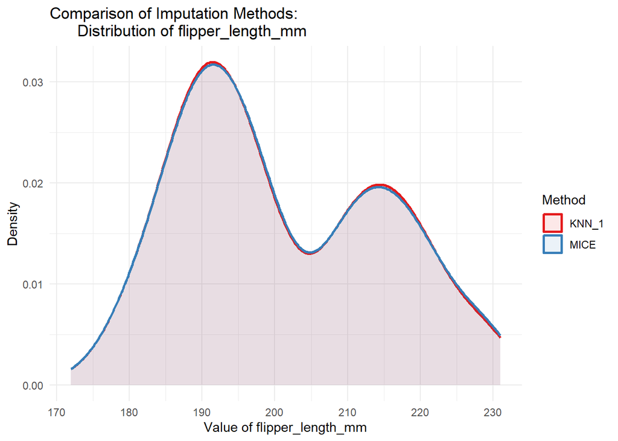

[figure not shown]

```r
## k-NN and MICE imputations
df_1nn <- kNN(df, k = 1, imp_var=FALSE)
imp_mice <- mice(df, m = 5, printFla=FALSE) #number of default imputations, PARA ENRIQUE: NO SE SI CALDRIA FER-NE DE MES O DE MENYS O FEM TOT BY DEFAULT
df_mice <-complete(imp_mice)

## Code provided for the plots
plot_columns <- cols[-c(1,6)]

for (column in plot_columns){
  comparison_df <- data.frame(
  KNN_1    = df_1nn[[column]],
  MICE     = df_mice[[column]]
  )
  plot_data <- comparison_df %>%
    pivot_longer(cols = everything(), names_to = "Method", values_to = "Value")

  p <- ggplot(plot_data, aes(x = Value, color = Method, fill = Method)) +
    geom_density(alpha = 0.1, linewidth = 1) +
    labs(
      title = "Comparison of Imputation Methods:
      Distribution of flipper_length_mm",
      x = "Value of flipper_length_mm",
      y = "Density"
    ) +
    theme_minimal() +
    scale_color_brewer(palette = "Set1") +
    scale_fill_brewer(palette = "Set1")

  print(p)

}
```

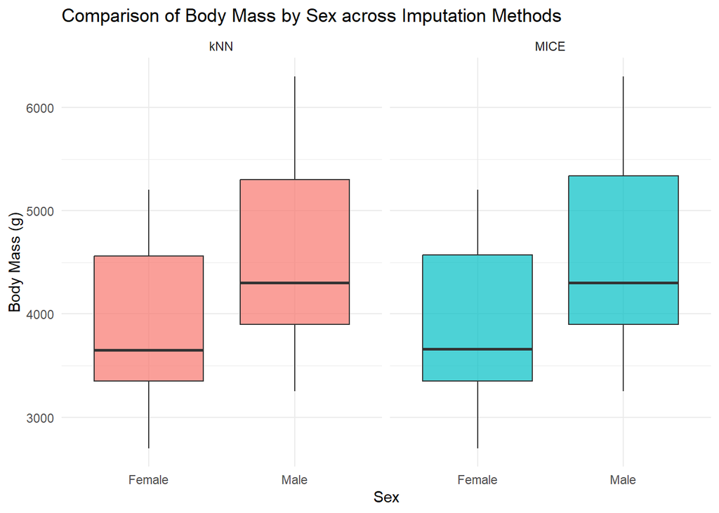

```r
subset_knn <- df_1nn %>%
  select(body_mass_g, sex) %>%
  mutate(Method = "kNN")

subset_mice <- df_mice %>%
  select(body_mass_g, sex) %>%
  mutate(Method = "MICE")

df_comparison <- bind_rows(subset_knn, subset_mice)

df_comparison <- df_comparison %>%
  mutate(sex = factor(sex, labels = c("Female", "Male")))

ggplot(df_comparison, aes(x = sex, y = body_mass_g, fill = Method)) +
  geom_boxplot(alpha = 0.7) +
  facet_wrap(~ Method) +
  labs(
    title = "Comparison of Body Mass by Sex across Imputation Methods",
    x = "Sex",
    y = "Body Mass (g)"
  ) +
  theme_minimal() +
  theme(legend.position = "none")
```

Once the computations are performed, it’s difficult to observe any differences between the results of both imputation methods, as they are almost identical at first sight. Density plots reveal similar shapes, and boxplot show very similar medians and IQRs.

To determine which method produces better results, we must consider their characteristics and properties, according to the methodologies used for computation. Thus being:

- 1-NN: it only uses values that actually exist in our data so the generating mechanism produces them. It is sensitive to outliers.
- MICE: it preserves the distribution (mean and variance). It accounts for statistical uncertainty, therefore and shows better performance than 1-NN when working with datasets with higher rates of missingness.

Nonetheless, if we had to choose one method over the other, we would stick with k-NN because the data we are working with has low missingness and low dimensionality. Also, k-NN can handle local groupings (keep in mind we are working with different types of penguin species).

MICE would outperform k-NN if we were working with a much higher missingness ratio and a high-dimensional dataset. However, it is more computationally costly.

## The other way

**Q7: Using the data frame with imputed data (KNN and MICE), repeat the outlier analysis (steps Q1-Q4). Compare the results of the two approaches: performing outlier analysis on a complete-case dataset (removing NAs) versus imputing missing values before conducting the outlier analysis.**

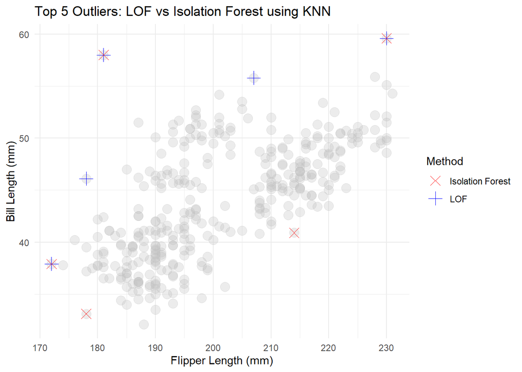

```r
# kNN data
# Select study vars (flipper lenght, bill length)
df.knn <- df_1nn[,c("flipper_length_mm", "bill_length_mm")]

# Compute LOF scores k = 20
lof_scores <-lof(df.knn, k=20) #set k to 20
#Set threshold
thr_lof <-quantile(lof_scores, 0.975, type = 7) #type 7 by default

# Classify outliers according to threshold
df.knn$outlier_lof <-ifelse(lof_scores >= thr_lof, "Outlier", "Normal")

# Identify Top 5 outliers
top5_idx_lof <-order(lof_scores, decreasing = TRUE) [1:5] #top 2.5% obs LOF score > 9.1 classified as outlier
df.knn$outlier_lof[top5_idx_lof] <- "Top 5 Outliers"


iso_forest <-isolation.forest(df.knn, ndim=2, ntrees = 100) #set ntrees to 100
iso_scores <-predict(iso_forest, df.knn, type = "score")

# Set threshold
thr_iso <-quantile(iso_scores, 0.975, type = 7) #type 7 by default

# Classify outliers according to threshold
df.knn$outlier_iso <-ifelse(iso_scores >= thr_iso, "Outlier", "Normal")

# Identify Top 5 outliers
top5_idx_iso <-order(iso_scores, decreasing = TRUE) [1:5] #top 2.5% obs are considered outliers
df.knn$outlier_iso[top5_idx_iso] <- "Top 5 Outliers"

ggplot(df.knn, aes(x = flipper_length_mm, y = bill_length_mm)) +
  geom_point(color = "grey", size = 4, alpha = 0.3) +
  geom_point(data = df.knn[df.knn$outlier_lof == "Top 5 Outliers", ],
             aes(color = "LOF"), size = 4, shape = 3) +
  geom_point(data = df.knn[df.knn$outlier_iso == "Top 5 Outliers", ],
             aes(color = "Isolation Forest"), size = 4, shape = 4) +
  scale_color_manual(values = c("LOF" = "blue", "Isolation Forest" = "red")) +
  labs(title = "Top 5 Outliers: LOF vs Isolation Forest using KNN",
       x     = "Flipper Length (mm)",
       y     = "Bill Length (mm)",
       color = "Method") +
  theme_minimal()
```

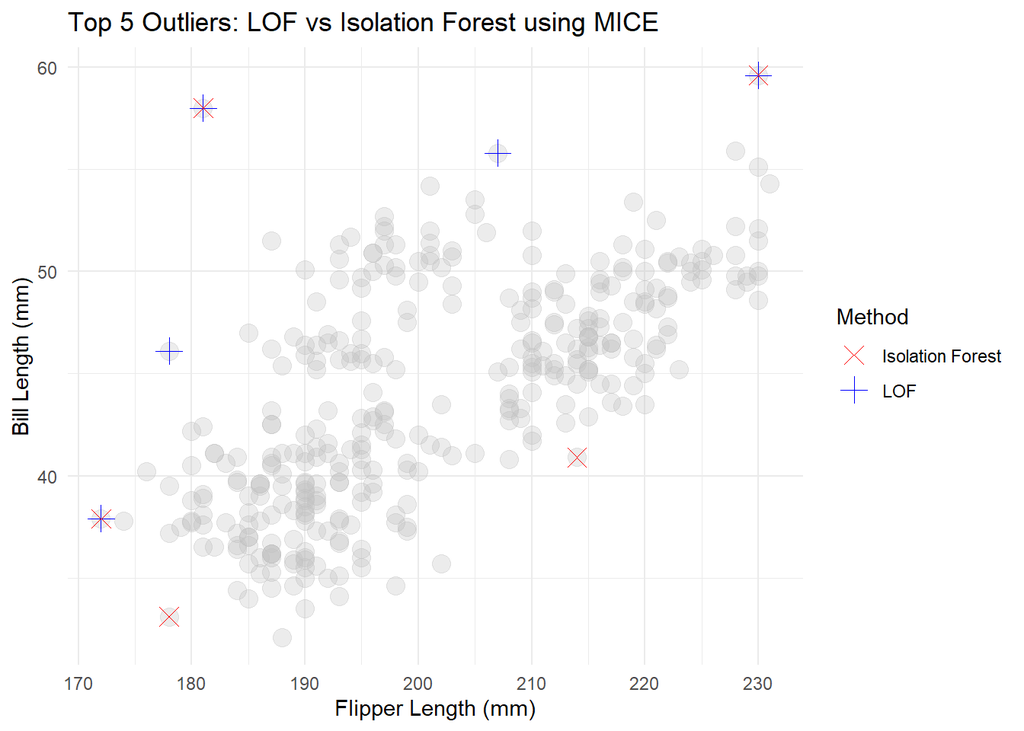

```r
# MICE data
# kNN data
# Select study vars (flipper lenght, bill length)
df.mice <- df_mice[,c("flipper_length_mm", "bill_length_mm")]

# Compute LOF scores k = 20
lof_scores <-lof(df.mice, k=20) #set k to 20
#Set threshold
thr_lof <-quantile(lof_scores, 0.975, type = 7) #type 7 by default

# Classify outliers according to threshold
df.mice$outlier_lof <-ifelse(lof_scores >= thr_lof, "Outlier", "Normal")

# Identify Top 5 outliers
top5_idx_lof <-order(lof_scores, decreasing = TRUE) [1:5] #top 2.5% obs LOF score > 9.1 classified as outlier
df.mice$outlier_lof[top5_idx_lof] <- "Top 5 Outliers"


iso_forest <-isolation.forest(df.mice, ndim=2, ntrees = 100) #set ntrees to 100
iso_scores <-predict(iso_forest, df.mice, type = "score")

# Set threshold
thr_iso <-quantile(iso_scores, 0.975, type = 7) #type 7 by default

# Classify outliers according to threshold
df.mice$outlier_iso <-ifelse(iso_scores >= thr_iso, "Outlier", "Normal")

# Identify Top 5 outliers
top5_idx_iso <-order(iso_scores, decreasing = TRUE) [1:5] #top 2.5% obs are considered outliers
df.mice$outlier_iso[top5_idx_iso] <- "Top 5 Outliers"

ggplot(df.mice, aes(x = flipper_length_mm, y = bill_length_mm)) +
  geom_point(color = "grey", size = 4, alpha = 0.3) +
  geom_point(data = df.mice[df.mice$outlier_lof == "Top 5 Outliers", ],
             aes(color = "LOF"), size = 4, shape = 3) +
  geom_point(data = df.mice[df.mice$outlier_iso == "Top 5 Outliers", ],
             aes(color = "Isolation Forest"), size = 4, shape = 4) +
  scale_color_manual(values = c("LOF" = "blue", "Isolation Forest" = "red")) +
  labs(title = "Top 5 Outliers: LOF vs Isolation Forest using MICE",
       x     = "Flipper Length (mm)",
       y     = "Bill Length (mm)",
       color = "Method") +
  theme_minimal()
```

Both 1nn and MICE imputation approaches converge to the same outliers, which was to be expected given that distributions and boxplots were nearly identical.

However, respect outlier treatment with the complete-case dataset, we do find a single difference for both the LOF and isolation tree algorithms

Given that the outliers were the same with the exception of this single point, we can say that using a technique or the other has no significant effect for this dataset.

## Multivariate matrices

Using the data without missing values (complete cases: `df_clean`) answer the following questions:

**Q8: Compute the sample mean vector** $m$, the centering matrix $H$ and the centered data matrix $X_c$. Only matrix and vector operations are allowed.

The sample mean vector $m$ is defined as:

$\mathbf{m}_{p \times 1} = \frac{1}{n} \left( \mathbf{1}^T X \right)^T$

The centering matrix $H$ is defined as:

$H = I - \frac{1}{n} \mathbf{1} \mathbf{1}^T$

To obtain the centered data matrix $X_c$ we must operate:

$X_c = X - \mathbf{1}_{n \times 1} m^T = X - \frac{1}{n} \mathbf{1} \mathbf{1}^T X = \left( I - \frac{1}{n} \mathbf{1} \mathbf{1}^T \right) X$

Which can be synthesized as: $X_c = H X$

```r
##Previous steps

# Create matrix X
X <-as.matrix(df_clean[, sapply(df_clean, is.numeric)])

# Define terms
nX <- nrow(X) #Number of obs
pX <- ncol(X) #Number of vars
one_n <- matrix(1, nX, 1) #For easier calculations: create vector 1 with n dimensions
I_n <- diag(nX) #For easier computations

## Computation of the sample mean vector m (px1)
m <- (1 / nX) * t(one_n) %*% X

## Computation of the centering matrix H
H <- I_n - (1 / nX) * one_n %*% t(one_n)

## Computation centered data matrix Xc
X_c <- H %*% X
print('Means by column of centered data matrix')
```

```
## [1] "Means by column of centered data matrix"
```

```r
round(apply(X_c, 2, mean), 2)
```

```
##    bill_length_mm     bill_depth_mm flipper_length_mm       body_mass_g
##                 0                 0                 0                 0
##               sex
##                 0
```

**Q9: Using the centered data matrix compute the sample covariance matrix** $S$. Only matrix and vector operations are allowed.

The sample covariance matrix $S$ is defined as: $S = \frac{1}{n-1} X_c^T X_c$

```r
## Computation of sample covariance matrix S
(S <- (1 / (nX - 1)) * t(X_c) %*% X_c)
```

```
##                   bill_length_mm bill_depth_mm flipper_length_mm body_mass_g
## bill_length_mm        29.9063334     -2.462091         50.058195   2595.6233
## bill_depth_mm         -2.4620913      3.877888        -15.947248   -748.4561
## flipper_length_mm     50.0581949    -15.947248        196.441677   9852.1916
## body_mass_g         2595.6233040   -748.456122       9852.191649 648372.4877
## sex                    0.9422012      0.367478          1.790812    171.3537
##                           sex
## bill_length_mm      0.9422012
## bill_depth_mm       0.3674780
## flipper_length_mm   1.7908119
## body_mass_g       171.3536579
## sex                 0.2507327
```

**Q10: Obtain the standardized data matrix** $X_s$ and use it to compute the sample correlation matrix $R$. Only matrix and vector operations are allowed.

The standardized data matrix is defined as follows:

$X_s = X_c D_s^{-1}$

where $D_s$ is expressed as: ${diag}(s_1, s_2, \dots, s_p)$; and where $X_s$ can also be expressed as $X_s = H X D_s^{-1}$

The sample correlation matrix $R$ is defined as:

$R = D_s^{-1} S D_s^{-1} = \frac{1}{n-1} X_s^T X_s$

```r
## Previous calculations
#std_devs <- apply(X_c, 2, sd) #sd for each var
D_s <- diag(diag(sqrt(S))) #creation diag matrix Ds
## Computation of the standardized data matrix Xs
X_s <- X_c %*% solve(D_s)

print('Sd by column of standardized data matrix')
```

```
## [1] "Sd by column of standardized data matrix"
```

```r
round(apply(X_s, 2, sd), 2)
```

```
## [1] 1 1 1 1 1
```

```r
## Computation of the sample correlation matrix R
#R <- solve(D_s) %*% S %*% solve(D_s)
(R = 1/(nX-1) * t(X_s) %*% X_s)
```

```
##            [,1]       [,2]       [,3]       [,4]      [,5]
## [1,]  1.0000000 -0.2286256  0.6530956  0.5894511 0.3440778
## [2,] -0.2286256  1.0000000 -0.5777917 -0.4720157 0.3726733
## [3,]  0.6530956 -0.5777917  1.0000000  0.8729789 0.2551689
## [4,]  0.5894511 -0.4720157  0.8729789  1.0000000 0.4249870
## [5,]  0.3440778  0.3726733  0.2551689  0.4249870 1.0000000
```